# Donna Moss for Senate: Follow-up Survey Results

Cara Feldkamp  
May 10, 2019

### Sample Pool and Demographics

- Unweighted: **n = 1083**
- Weighted: **n = 1065.5**
- Survey margin of error = **+/- 3 percentage points**

### Sample Pool: Weighting

- Weighting did not drastically change the breakdown by gender

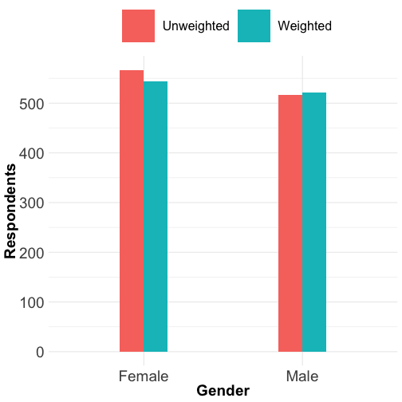

### Sample Pool: Weighting

- The breakdown by race also remained largely unchanged by weighting
- Note: there was only one Middle Eastern respondent

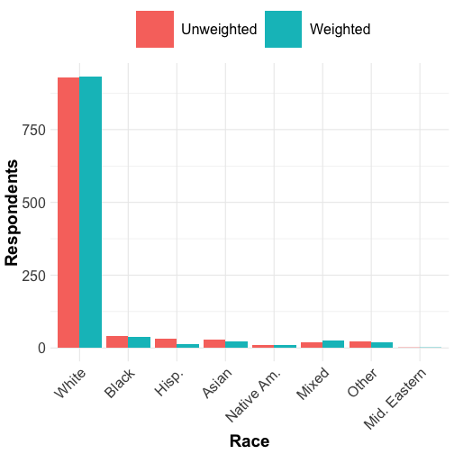

### Sample Pool: Weighting

- The weights had more of an affect on the breakdown by education level, as more highly educated individuals were overrepresented in the sample

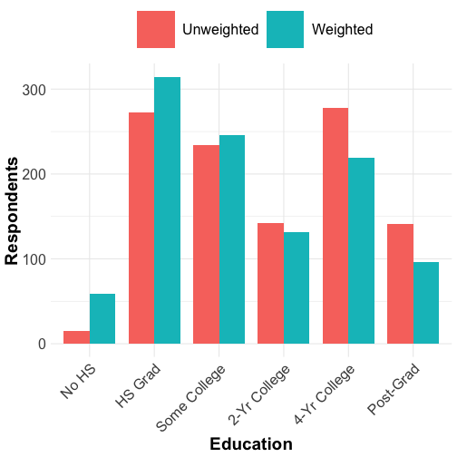

### Sample Pool: Weighting

- Likewise, Democrats and Independents were overrepresented in the sample and were downweighted.

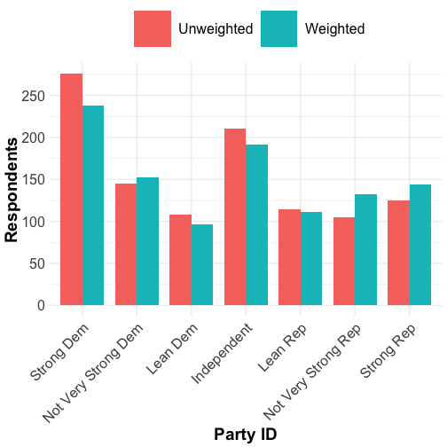

### Survey Results

- **We followed up on on our previous survey with questions about:**
  - The state of the race
  - Turnout/Voting likelihood
  - Political party ID
  - Political ideology
  - Approval of Trump
  - Opinion on repealing the Affordable Care Act

### Survey Results: Support and Turnout

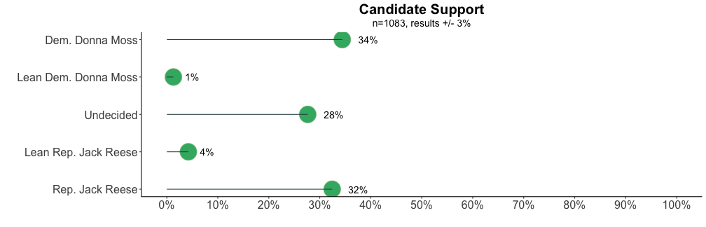

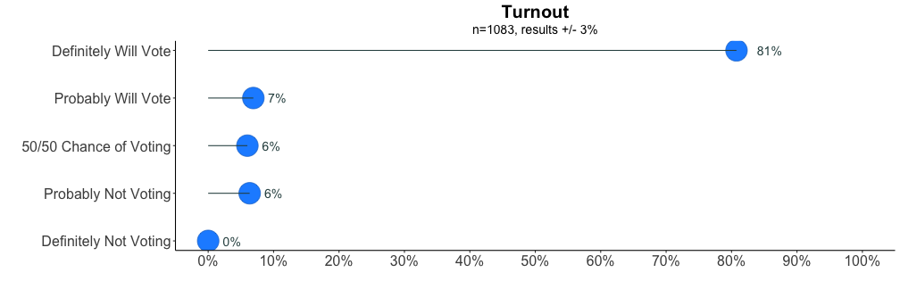

### Insights: Support and Turnout

- **The race is neck-in-neck at this point**, with Donna polling at 34%, Jack polling at 32%, and a margin of error of 3 percentage points.
- Even if all of the “Lean Donna” voters voted for Donna and all of the “Lean Jack” voters voted for Jack, the difference in vote share would still be within the margin of error.
- **More than a quarter of the electorate is undecided.**

### Insights: Support and Turnout

- **The race is still too close to call**, even when broken down by turnout. All 3 of Donna's apparent leads among people who may vote are within their respective margins of error (+/- 1.3%, 1.1%, and 1.0%).

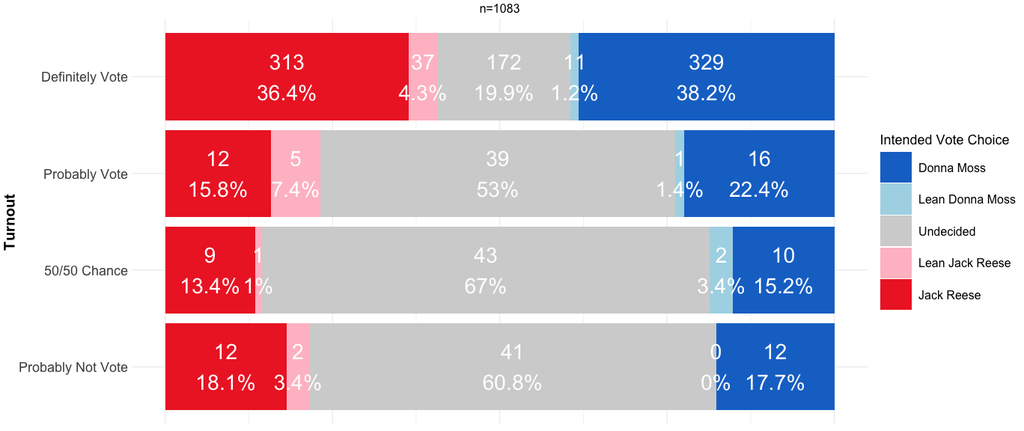

### Insights: Support and Turnout

- **54.57% of women** (+/- 4%) support or are leaning toward Donna, versus **45.43% of men** (+/- 4%).

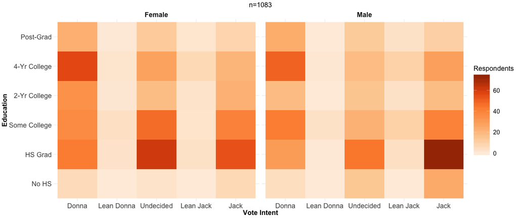

### Insights: Support and Turnout

- Donna is well-liked by both men and women with bachelor’s degrees, but **has less support among voters without a college degree**. College-educated people are likely to be a good source of volunteers, and the earlier we can recruit and train them, the better.

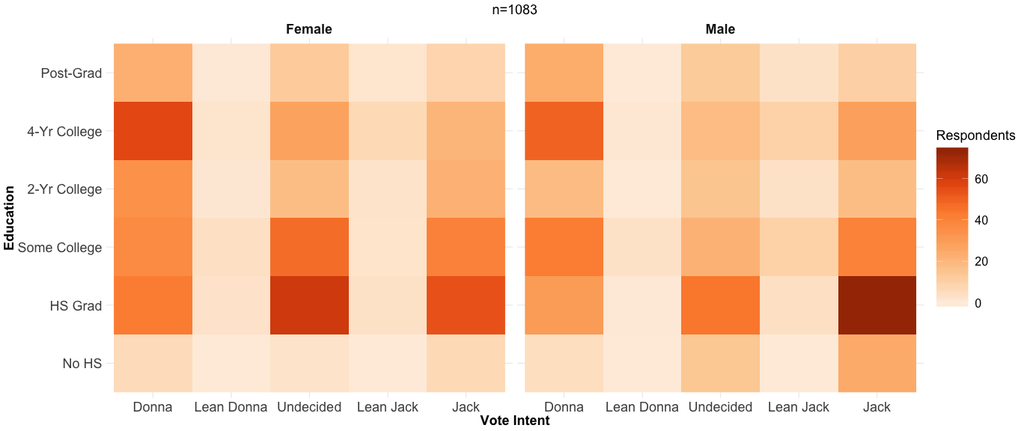

### Insights: Support and Turnout

- Undecided women with high school diplomas make up 11.22% of female voters. **We should increase our efforts to engage them**. Messaging that emphasizes Donna’s background as a college dropout before joining the Bartlet administration may help these voters connect with her.

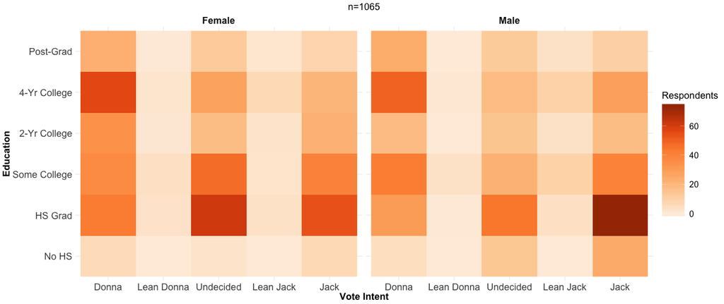

### Insights: Support and Turnout

- Donna is unpopular among men with a high school diploma. Unsurprisingly, this group strongly overlaps with Trump approval, wanting the ACA repealed, and “Definitely Will Vote.” They comprise 14% of male voters and 7% of the electorate, so **we should adjust our win number accordingly**.

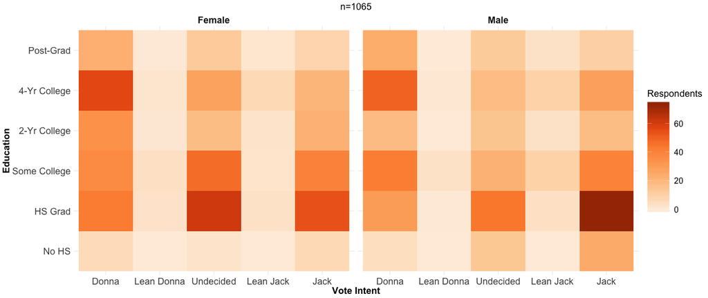

### Insights: Support and Turnout

- Who are the undecided voters?
- **We ran some regressions to determine what characteristics differentiate them** (Note: we removed the sole Middle-Eastern respondent from the models to get a more accurate prediction based on race).
- We found that, controlling for gender, education, and race, **Asian, Hispanic, and Black** respondents were slightly more likely to be undecided and **male respondents were slightly less likely to be undecided.**
- When we controlled for respondents' answers to the “ideology” question in addition to the above, **Asian voters were still more likely to be undecided.**

### Insights: Support and Turnout

**Model 1**: Predicting Undecided or not using gender, education level, and race

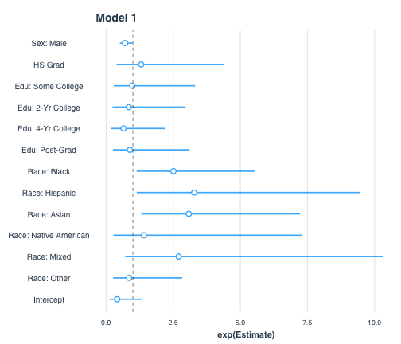

**Model 2**: Same as Model 1, plus answers to the “Ideology” question. **Coefficients (odds ratios) are below.**

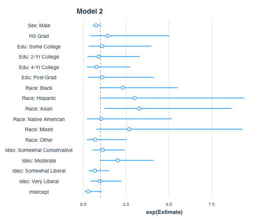

### Insights: Support and Turnout

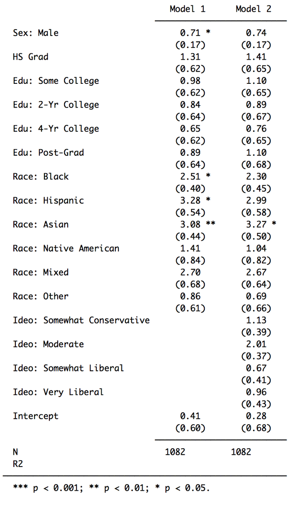

- In both models, Asian voters seem to be associated with being undecided, controlling for all else.
- However, CIs and std. errors are large here, so we should watch to see if this association holds given more data.
- We converted the odds ratios to predicted probabilites (next slide) and compared them to the data.

### Insights: Support and Turnout

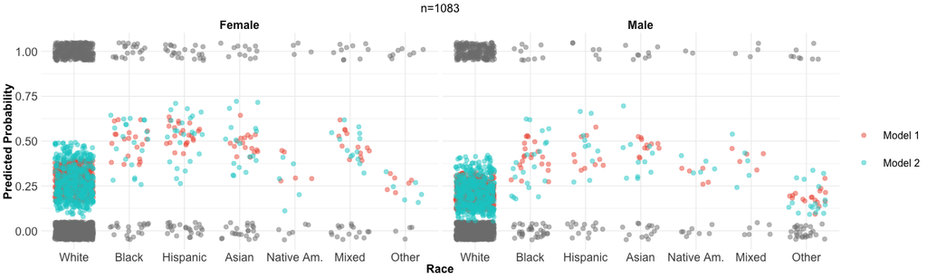

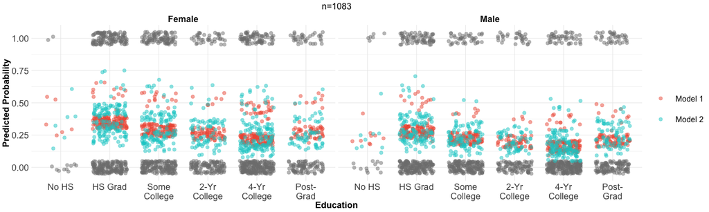

### Insights: Support and Turnout

- We can see that while neither model is especially accurate in predicting undecidedness, both seem to capture the general trends in the data to some extent. **If these trends hold given additional data, we should consider creating some demographically-targeted outreach programs.**
- Unsurprisingly, **Model 2 does a better job of capturing the variance in undecidedness**, which we confirmed via a Likelihood Ratio Test. However, without a measure of someone's political ideology, race, education and gender do appear to be somewhat useful in estimating how likely someone is to be undecided.
- These distributions also hint at an interaction between education and race, but the sample size would be too small at this point to draw useful conclusions from it.

### Survey Results: Party ID and Ideology

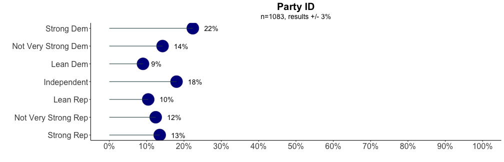

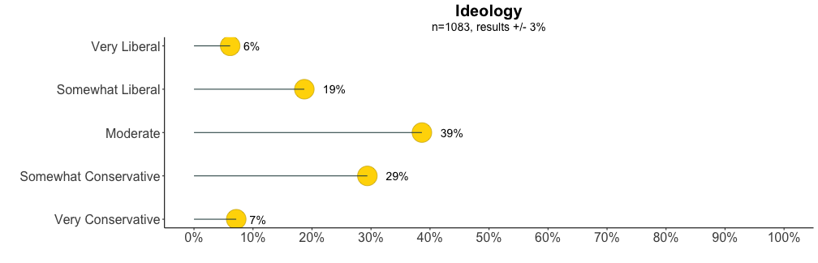

### Insights: Party ID and Ideology

- Donna is more popular among Dem-leaners (57.9% +/- 1.3%), than “not very strong” Dems (53.4% +/- 1.3%). **We should incorporate some lukewarm Democrats into our persuasion universe**. They will likely support Donna, but may need a touch from the campaign to feel included and to turn out.

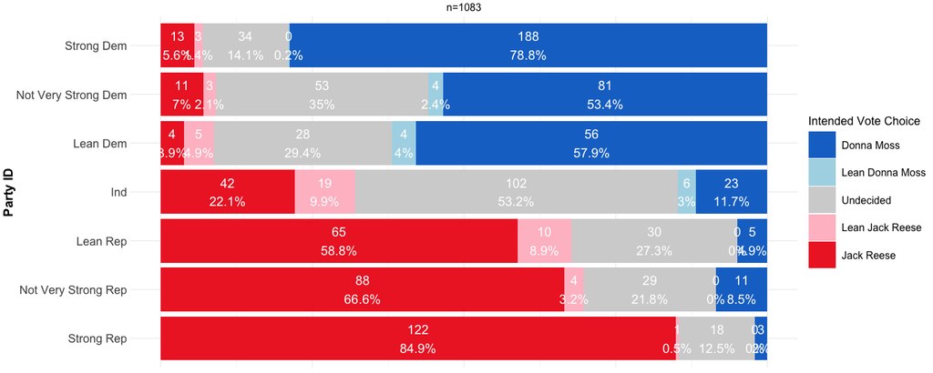

### Insights: Party ID and Ideology

- Moderates and Independents overlap, but **more self-described Moderates lean Dem** than GOP, while **Independents lean slightly more conservative** than liberal.

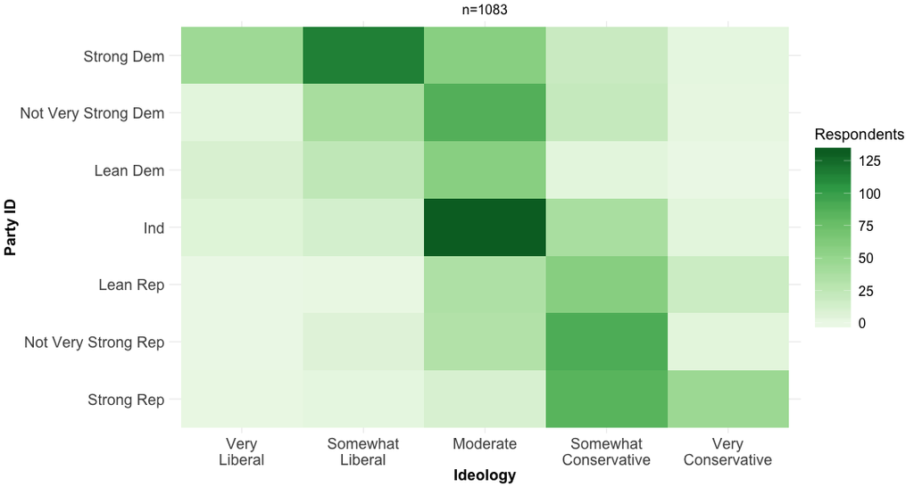

### Insights: Party ID and Ideology

- Even when we reduced the number of Dems and increased the number of GOP by their margins of error, **13.2% more Moderates identified more with Dems** than Republicans.

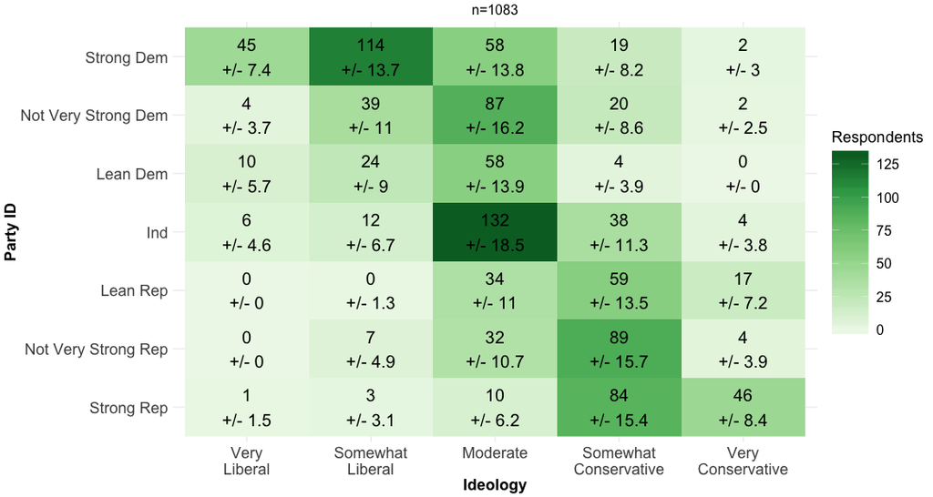

### Insights: Party ID and Ideology

- We still have some ground to cover with Somewhat Liberals and Moderates who may be persuadable
- We should also aim to **give leaners and undecideds who are Very Liberal a touch before GOTV**

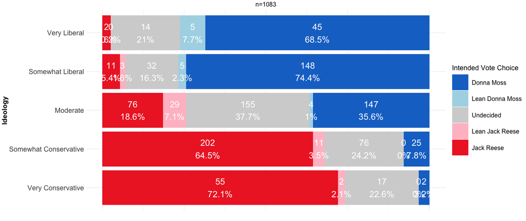

### Survey Results: Trump Approval and ACA

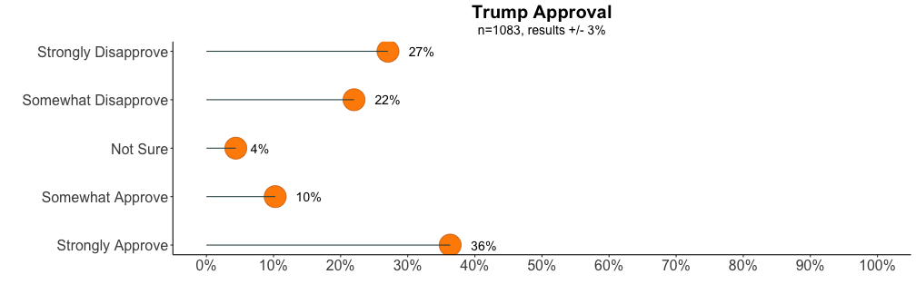

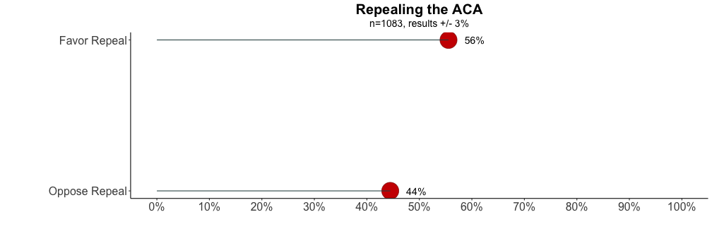

### Insights: Trump Approval and ACA

- Trump approval/disapproval is within the margin of error for both Undecideds and Donna-leaners.
- For the time being, campaign messaging should avoid criticizing Trump too harshly and **stick to positive statements about our candidate.**

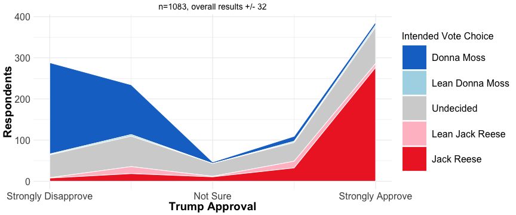

### Insights: Trump Approval and ACA

- Undecided voters tend to favor repeal: **62.4% Favor**, 37.6% Oppose +/- 5.5%, while Donna-Leaners are split
- White voters are the most likely to favor repealing the ACA

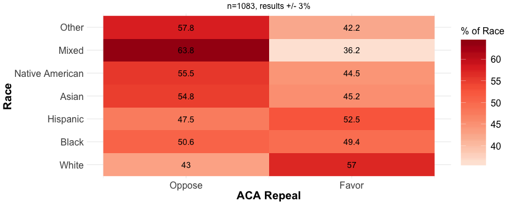

### Insights: Party ID and Ideology

- While more undecided Moderates favor repealing the ACA, we can work to persuade the undecided voters who oppose.
- We also suggest **including a brief issue-ranking question** in the next version of the survey to learn more about these moderates’ concerns and priorities.

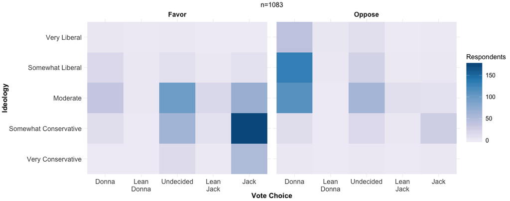

### Proposed Campaign Strategy Updates

- **At this point in the campaign, we should aim to:**
  - ID as many voters as possible
  - Gather more data to confirm whether the subgroup trends we found hold
  - Organize supporters at the community level and build grassroots infrastructure
  - Learn more about voters who are undecided and/or leaning toward Donna and speak to their specific interests and concerns

### Proposed Campaign Strategy Updates

- **To accomplish these goals, we can:**
  - Run a survey with an issue-ranking question to home in on the priorities of moderates and undecideds
  - Start persuasion outreach to undecided voters and people who vote for Dems inconsistently
  - Start drafting targeted outreach plans to engage working-class women, Asian-American voters, and other demographic groups who may be more likely to be undecided
  - Hire organizers who can start to build grassroots outreach teams in the communities we want to target
  - Adjust our win number to account for strong Jack Reese support from working-class men.